# Final Data Section

Group 1-Josh Yamamoto, Riley Leonard, Andy Zhao

## Data and Results

After describing some of the trends we observed in the data, we then turn towards the variety of models that we have created, as well as their respective performances, measured in adjusted R-squared as well as 5-fold cross-validation mean-squared error (MSE).

### Full Model

```r
# Full Model for ERA

full_mod <- lm(data = pitchers,
                 ERA_t1 ~.)

# Full Model for Salary

full_mod <- lm(data = salary_data,
                 salary_t1 ~.)
```

Above, we see the code for the full model on both salary and ERA. We expected that the full model would do adequetely, as we had hand-selected every variable included in our dataset and thus we expected all of our variables to be at least somewhat significant. However, one of the issues we had foresaw was the presence of a great deal of collinearity, which could make our parameter estimates quite unstable, and the full model lacks the sufficient means to counter said collinearity.

#### Full Model Results

| Adjusted R-squared and 5-Fold CV MSE | Full Model Statistics |
| --- | --- |
| R-Squared on Salary | 0.609 |
| 5-fold MSE on Salary | 0.831 |
| R-Squared on ERA | 0.140 |
| 5-Fold MSE on ERA | 1.043 |

### Forward Selection

```r
# Forward Selection Model for ERA

forward_mod <- lm(data = pitchers,
                   ERA_t1 ~ wOBA + L + BFP + SO + K_percent + hard_hit_percent +
                    barrel_percent + `ERA/Barrel %` + luck_adj_ERA)

# Forward Selection Model for Salary

forward_mod_salary <- lm(data = salary_data,
                         log(salary_t1) ~ Pitches + Year + xBA + spin_rate +
                           Velocity + K_percent + Salary + luck_adj_ERA)
```

We then moved on to forward selection, which is an efficient alternative to best subset. We set the maximum complexity of the model (nvmax) to be considered at 12. We chose this because of the aforementioned problems with collinearity. Subset selection gives us a way to reduce collinearity by simply dropping some of the correlated predictors. We set the maximum to 12 because we wanted a relatively parsimonious model. Ultimately, the adjusted R-squared of the model with 9 predictors performed the best among all the 12 ERA models, while the 8-predictor model performed the best for salary.

While a more detailed discussion will be left for the conclusion, in broad strokes, the predictors included in the two models are not as different as one would expect. The presence of expected batting averaged (xBA) and spin rate in the salary model suggests that these sabermetric statistics actually result in a larger contract, but, conversely, base counting statistics like total pitches and even year is also included.

The forward model for ERA includes a number of advanced statistics such as wOBA, hard hit %, barrel %, and even ERA/barrel %. However, it also includes counting statistics like total strikeouts and total batters faced. Ultimately, the forward model for the two are more similar than one would have intuited.

#### Forward Selection Results

| Adjusted R-squared and 5-Fold CV MSE | Forward Model Statistics |
| --- | --- |
| R-Squared on Salary | 0.617 |
| 5-fold MSE on Salary | 0.766 |
| R-Squared on ERA | 0.164 |
| 5-Fold MSE on ERA | 0.999 |

The forward selection method of subset selection led to improvements over the full model, likely due to reduction in collinearity by dropping some of the correlated predictors. Interestingly, the improvement is quite marginal and did not lead to as major of an increase in 5-fold CV MSE or adjusted R-squared as one would have predicted.

### Ridge and LASSO Regression

Both forms of penalized regression---ridge and LASSO---struck us as potentially valuable in that the full model performed fairly well on its own, thus a penalized regression might improve its accuracy by potentially reducing variance with only a small concomittant increase in bias. Due to the large number of predictors in the full model (30), we were quite concerned about variance and thus hoped that ridge and LASSO would help.

```r
# Ridge Model for ERA

ridge_mod_ERA <- glmnet(x_full_model_ERA,
                       y_full_model_ERA,
                       alpha = 0,
                       lambda = best_L_ridge_ERA)

# Ridge Model for Salary

ridge_mod <- glmnet(x_full_model_salary,
                   y_full_model_salary,
                   alpha = 0,
                   lambda = best_L_ridge)

# Lasso Model for ERA

lasso_mod <- glmnet(x_full_model_salary,
                    y_full_model_salary,
                    alpha = 1,
                    lambda = best_L_lasso)

# Lasso Model for Salary

lasso_mod_ERA <- glmnet(x_full_model_ERA,
                        y_full_model_ERA,
                        alpha = 1,
                        lambda = best_L_lasso_ERA)
```

Above, we see the 4 models, one for salary and one for ERA for each of the penalized regressions. The best lambda value for cost-complexity tuning was determined through cross-validation using a range of values.

#### Ridge and LASSO Results

| Adjusted R-squared and 5-Fold CV MSE | Ridge Regression Statistics | Lasso Regression Statistics |
| --- | --- | --- |
| R-Squared on Salary | 0.625 | 0.630 |
| 5-fold MSE on Salary | 0.337 | 0.328 |
| R-Squared on ERA | 0.093 | 0.107 |
| 5-Fold MSE on ERA | 0.990 | 0.973 |

As we see, both forms of penalized regression led to pretty significant reductions in 5-fold CV MSE for both ERA and salary, but especially for salary. The CV MSE for salary was more than cut in half after applying the penalty to the full model. This suggests that the two methods achieved their desired function by trading off a small amount of bias for a larger decrease in variance.

Interestingly, LASSO performed better than ridge for both future salary and ERA. What this suggests is that, perhaps due to a high degree of correlation among predictors, certain predictor coefficients can be set to 0 in the interest of predictive accuracy. Similar to best subet, LASSO is performing variable selection (which perhaps explains its increased effectiveness).

### Principal Component Regression

Best subset offers us one solution against collinearity by dropping some of the correlated predictors. Principal component regression offers us another method by combining various predictors into new ones that adequately explain much of the variation in the data. By doing so, we can perhaps remedy some of the correlations among our predictors.

The number of principal components to use in each model was chosen based off crossed-validation. Interestingly, ERA only required 4 principal components, while salary required 13. This could suggest that, while 4 principal components are sufficient to capture the variability in future ERA, more principal components are necessary to capture the variance in future salary.

```r
# PCR Model for ERA

my_pcr_ERA <- pcr(formula = ERA_t1 ~ .,
                  ncomp = 4,
                  data = pitchers)

# PCR Model for Salary

my_pcr_salary <- pcr(formula = log(salary_t1) ~ .,
                     ncomp = 13,
                     data = salary_data)
```

#### PCR Results

| Adjusted R-squared and 5-Fold CV MSE | Principal Component Regression Statistics |
| --- | --- |
| R-Squared on Salary | 0.655 |
| 5-fold MSE on Salary | 0.331 |
| R-Squared on ERA | 0.139 |
| 5-Fold MSE on ERA | 0.997 |

While principal component regression did lead to an improvement from the full model, it did not lead to as much of an improvement as we expected. While PCR performed at around the same level as ridge, LASSO out-performed both ridge and PCR. It is also notable that ridge, LASSO, and PCR resulted in large reductions in salary 5-fold CV MSE but not for ERA, suggesting that the salary data benefits more from the various attempts at reducing collinearity.

### Custom Model

```r
# Custom Model for ERA

custom_mod <- lm(data = pitchers,
                  ERA_t1 ~ spin_rate + G + SO + K_percent +
                    ERA:hard_hit_percent + ERA:barrel_percent + luck_adj_ERA)
```

#### Custom Model Results

| Adjusted R-squared and 5-Fold CV MSE | Custom Model Statistics |
| --- | --- |
| R-Squared on Salary | 0.643 |
| 5-fold MSE on Salary | 0.329 |
| R-Squared on ERA | 0.157 |
| 5-Fold MSE on ERA | 0.972 |

### Overall Results

[output not shown]

| Model | Rsq for ERA | 5-fold MSE for ERA | Rsq for Salary | 5-fold MSE for Salary |
| --- | --- | --- | --- | --- |
| Ridge | 0.092 | 0.990 | 0.625 | 0.337 |
| Lasso | 0.107 | 0.973 | 0.629 | 0.328 |
| Forward | 0.164 | 0.999 | 0.616 | 0.765 |
| Custom | 0.157 | 0.972 | 0.643 | 0.329 |
| Full | 0.139 | 1.043 | 0.609 | 0.831 |
| PCR | 0.138 | 0.997 | 0.654 | 0.331 |
| Ensemble | 0.149 | 0.970 | 0.829 | 0.181 |

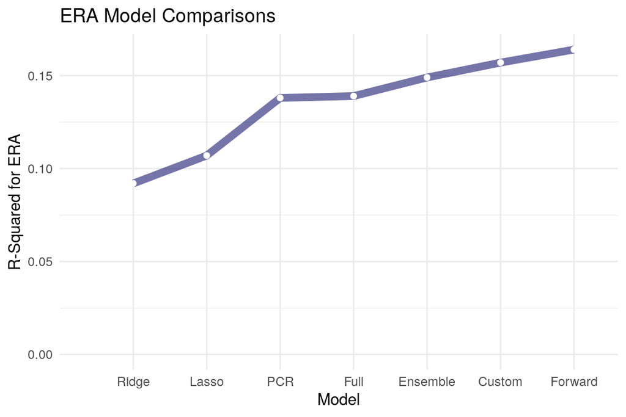

[figure not shown]

For salary, we can see that the ensemble model far outperforms the other models in terms of R-squared. Similarly, in terms of 5-fold MSE, we see that the ensemble model again outperforms all other models:

[figure not shown]

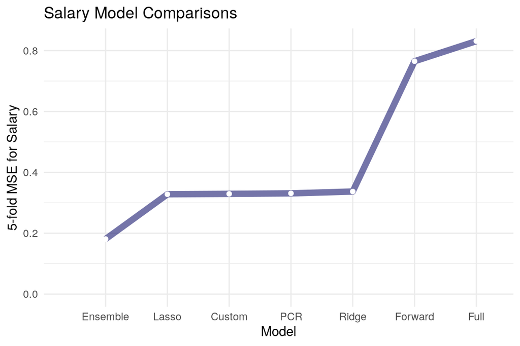

## Conclusions

We have split our conclusions into two parts, predictive and inferential. The reason for this was that the more complex ensemble models that excelled in prediction are not as amenable to interpretation as some simpler models (such as the custom linear regression models or the lasso penalized regression).

### Inferential Conclusions

```r
# Comparing Custom Models

custom_mod <- lm(data = pitchers,
                  ERA_t1 ~ spin_rate + G + SO + K_percent +
                    ERA:hard_hit_percent + ERA:barrel_percent + luck_adj_ERA)

custom_mod_salary <- lm(data = salary_data,
                         log(salary_t1) ~ Year + SO +
                           Salary + W*luck_adj_ERA)
```

Above, we see the two linear regressions we created for our custom models, which were built using domain knowledge to create initial multiple linear regressions, and then were fine-tuned by introducing interaction terms and performing manual stepwise selection by dropping insignificant predictors and adding new ones.

Custom ERA Model Coeffcients

|  | Estimate | Std. Error | t value | Pr(>\|t\|) |
| --- | --- | --- | --- | --- |
| (Intercept) | 7.163 | 0.998 | 7.176 | 0.000 |
| spin_rate | 0.000 | 0.000 | -0.735 | 0.463 |
| G | 0.019 | 0.017 | 1.106 | 0.269 |
| SO | -0.006 | 0.003 | -1.964 | 0.050 |
| K_percent | -4.553 | 2.172 | -2.096 | 0.037 |
| luck_adj_ERA | -0.685 | 0.322 | -2.128 | 0.034 |
| ERA:hard_hit_percent | 0.007 | 0.004 | 1.574 | 0.116 |
| ERA:barrel_percent | 0.024 | 0.011 | 2.141 | 0.033 |

Custom Salary Model Coeffcients

|  | Estimate | Std. Error | t value | Pr(>\|t\|) |
| --- | --- | --- | --- | --- |
| (Intercept) | 192.450 | 61.549 | 3.127 | 0.002 |
| Year | -0.088 | 0.031 | -2.894 | 0.004 |
| SO | 0.004 | 0.001 | 3.576 | 0.000 |
| Salary | 0.000 | 0.000 | 23.705 | 0.000 |
| W | -0.054 | 0.046 | -1.179 | 0.239 |
| luck_adj_ERA | -0.124 | 0.115 | -1.078 | 0.282 |
| W:luck_adj_ERA | 0.015 | 0.011 | 1.336 | 0.182 |

When it comes to performing interpretation on the models, we looked at both the predictors that were included as well as the significance (in p-value) of each predictor. First, looking at the ERA model, in terms of predictor inclusion, we see a mix of counting statistics such as games and strikeouts as well as advanced statistics such as spin rate, barrel %, and luck-adjusted ERA. Of the 7 variables, 2 of them fall into the counting statistics category, strikeout percent is unique in that it is a slightly processed form of a basic counting statistic, while the other 4 are closer to advanced statistics, suggesting that statistics-driven analytics might be more helpful in performing predictions of future ERA. Then, looking at significance, the interaction term bewteen ERA and barrel % stands out as having the smallest p-value. As previously discussed, this term attempts to remove some of the noise from the base ERA metric. The positive coefficient makes sense, as a higher ERA or higher barrel % is likely to lead to a higher ERA in the succeeding year. The next smallest p-value belongs to luck-adjusted ERA, which penalizes “lucky” pitchers with a regression to the mean of an aggregation of luck statistics. The other two predictors with low p-values were the related predictors of total strikeouts and strikeout rates, with strikeout rate having a lower p-value. The inclusion of the basic counting statistic of total strikeout as well as the minimally processed statistics of strikeout rates suggest that, while advanced analytics are most useful in the deternimation of future ERA, counting statistics still have an important role as well. Overall, even though the ERA prediction model integrates both counting statistics and advanced statistics, it seems like it relies quite heavily upon advanced analytics, even though basic metrics still play a role.

Lastly, we can compare the predictors included in each model, as well as their associated significance. Just from the basis of included predictors, we can already see a difference in terms of representation of advanced analytics. While the majority of predictors used in predicting ERA were advanced statistics such as hard-hit percent or barrel percent, those Sabermetric statistics don’t appear in the salary model, save for luck adjusted ERA. What this suggests is that front offices have perhaps not fully integrated Sabermetrics into their contract discussions. In fact, luck adjusted ERA can be switched out for ERA without any decrease in model accuracy for salary, suggesting that front offices have yet to discover or embrace the statistical concept of luck reversion.